# Part 2: Exploration

## Learning outcomes

**After having completed this chapter you will be able to:**

- Perform dimensionality reduction (PCA, UMAP) on single-cell data
- Integrate multiple samples to remove batch effects
- Cluster cells and evaluate clustering results
- Annotate cell types using marker genes and automated methods
- Visualize and interpret single-cell analysis results

## Dimensionality Reduction

```r
suppressPackageStartupMessages({
  library(Seurat)
  library(ggplot2)
  library(tidyverse)
})
scData <- qs2::qs_read("../scData_part1.qs2")
```

Once the data is normalized, scaled and variable features have been identified, we can start to reduce the dimensionality of the data. For the PCA, by default, only the previously determined variable features are used as input, but can be defined using features argument if you wish to specify a vector of genes. The PCA will only be run on the variable features, that you can check with `VariableFeatures(scData)`.

```r
scData <- Seurat::RunPCA(scData)
```

To view the PCA plot:

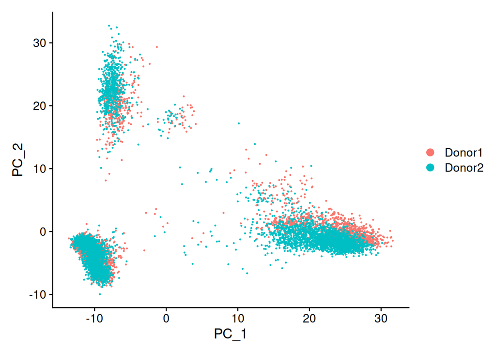

```r
Seurat::DimPlot(scData, reduction = "pca")
```

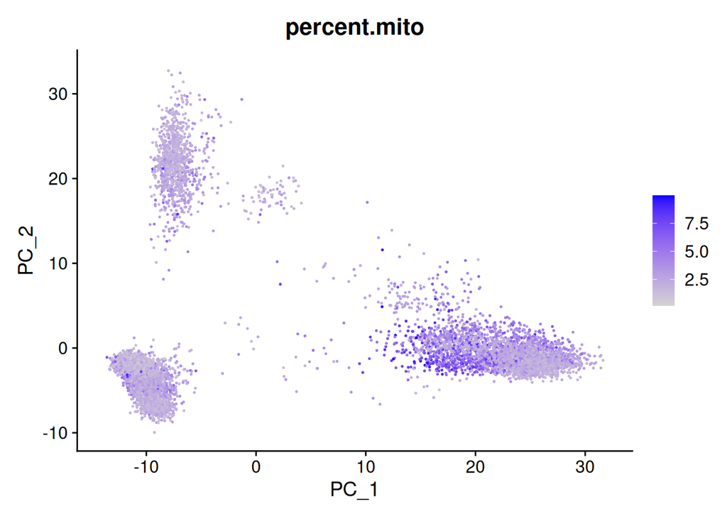

```r
Seurat::FeaturePlot(scData, reduction = "pca", features = "percent.mito")
```

Note that we used a different plotting function here: `FeaturePlot`. The difference between `DimPlot` and `FeaturePlot` is that the first allows you to color the points in the plot according to a grouping variable (e.g. sample) while the latter allows you to color the points according to a continuous variable (e.g. gene expression).

Generate a PCA plot where color is according to counts of a gene (i.e. gene expression). For example, you can take `HBA1` (alpha subunit of hemoglobin), or one of the most variable genes (e.g. `IFIT2`):

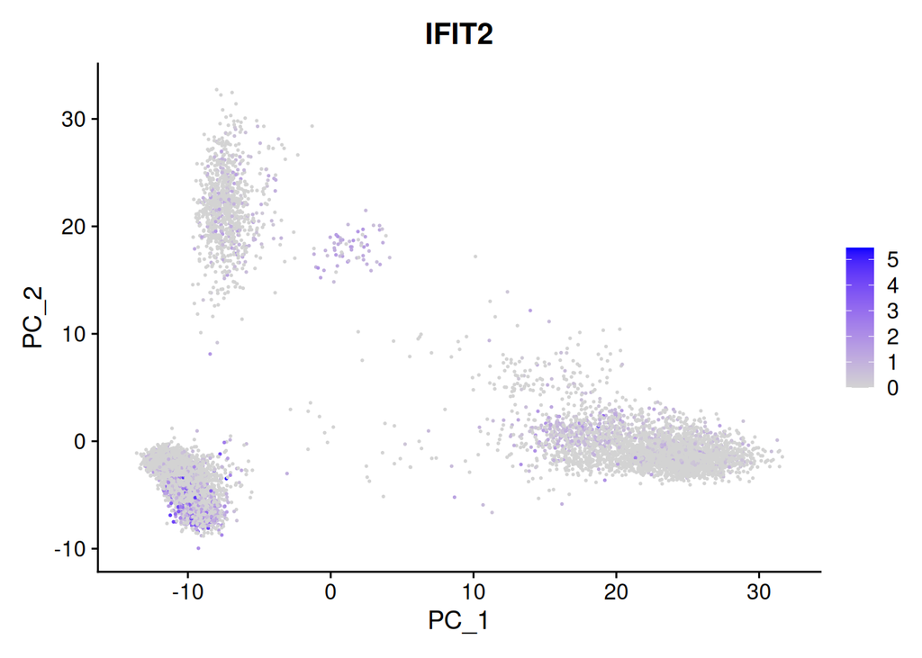

```r
Seurat::FeaturePlot(scData, reduction = "pca", features = "IFIT2")
```

We can generate heatmaps according to their principal component scores calculated in the rotation matrix:

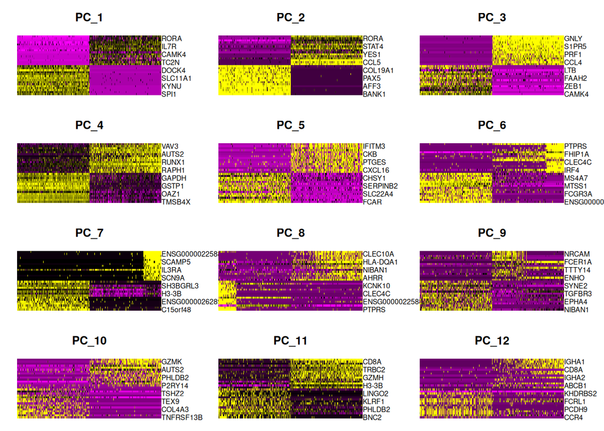

```r
Seurat::DimHeatmap(scData, dims = 1:12, cells = 500, balanced = TRUE)
```

The elbowplot can help you in determining how many PCs to use for downstream analysis such as UMAP:

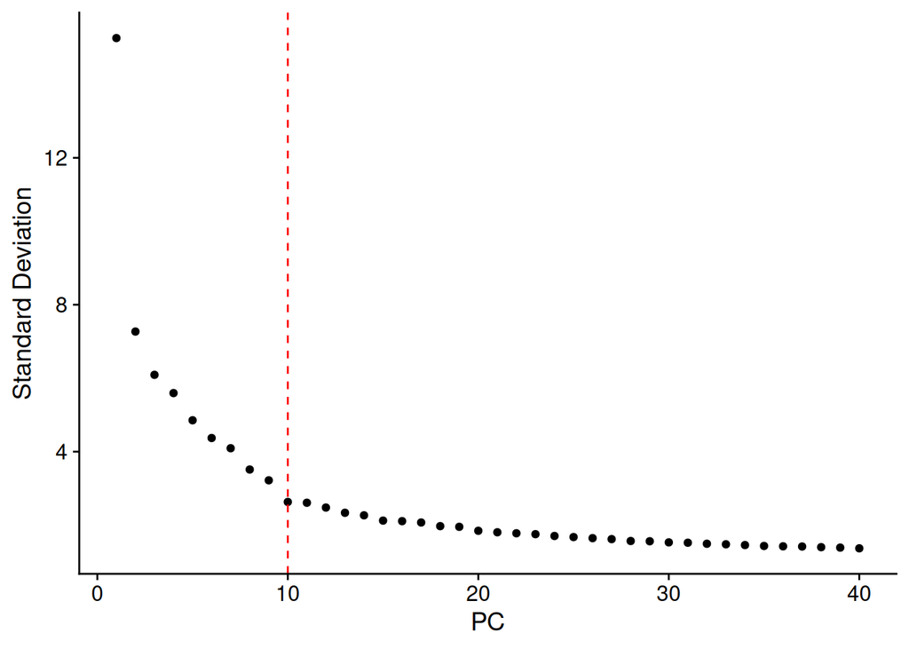

```r
Seurat::ElbowPlot(scData, ndims = 40) +
  geom_vline(xintercept = 10, linetype = "dashed", color = "red")
```

Including too many PCs usually does not affect much the result, while including too few PCs can affect the results very much.

UMAP: The goal of these algorithms is to learn the underlying manifold of the data in order to place similar cells together in low-dimensional space.

```r
scData <- Seurat::RunUMAP(scData, dims = 1:10)
```

To view the UMAP plot:

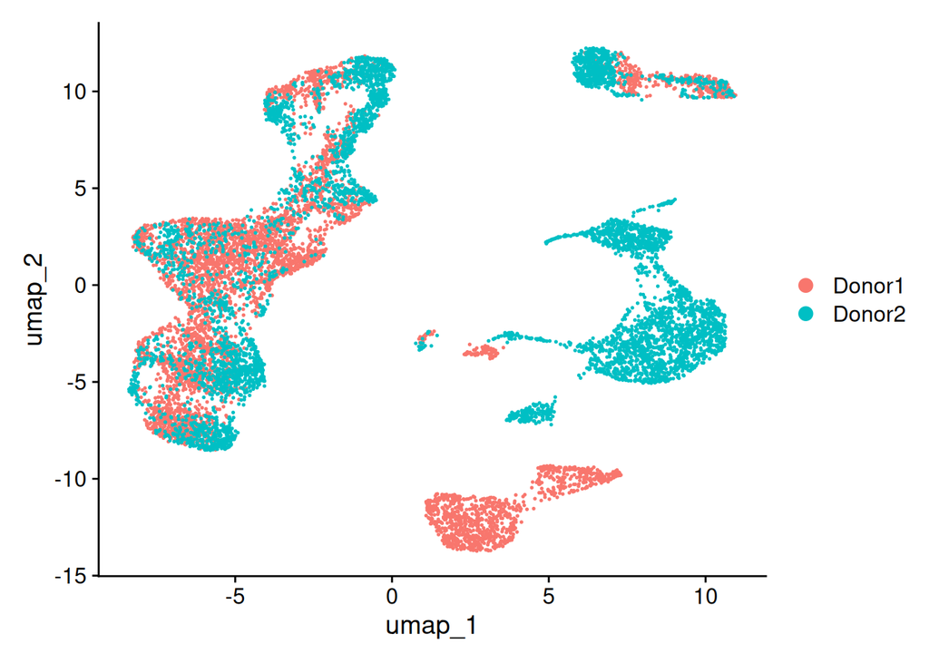

```r
Seurat::DimPlot(scData, reduction = "umap")
```

Try changing the color of the dots in the UMAP according to a variable (e.g. `percent.globin` or `HBA1`):

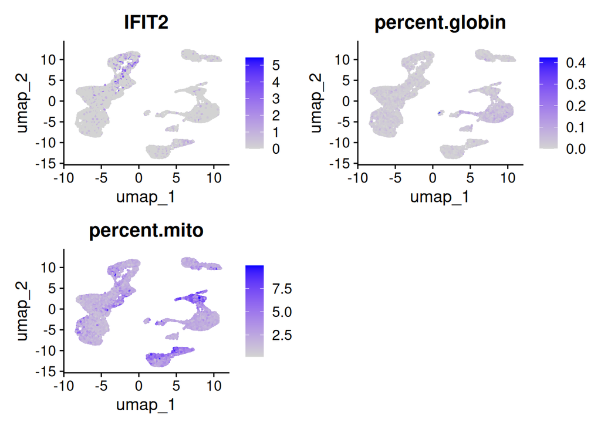

```r
Seurat::FeaturePlot(scData, features = c("IFIT2",
                                         "percent.globin",
                                         "percent.mito"))
```

You can experiment with UMAP parameters such as the number of neighbors:

```r
# Try different number of neighbors (default is 30)
scData <- Seurat::RunUMAP(scData, dims = 1:10, n.neighbors = 50)
```

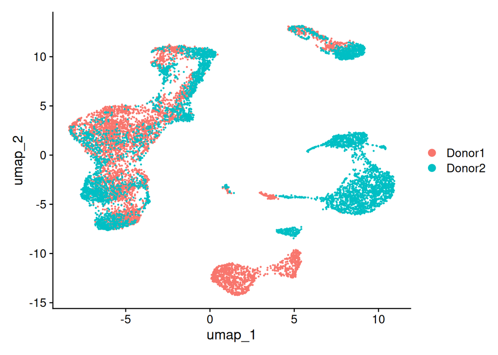

```r
Seurat::DimPlot(scData, reduction = "umap")
```

Reset to standard parameters for consistency:

```r
scData <- Seurat::RunUMAP(scData, dims = 1:10)
```

## Integration

Let’s have a look at the UMAP again. Although cells of different samples are shared amongst ‘clusters’, you can still see separation within the clusters:

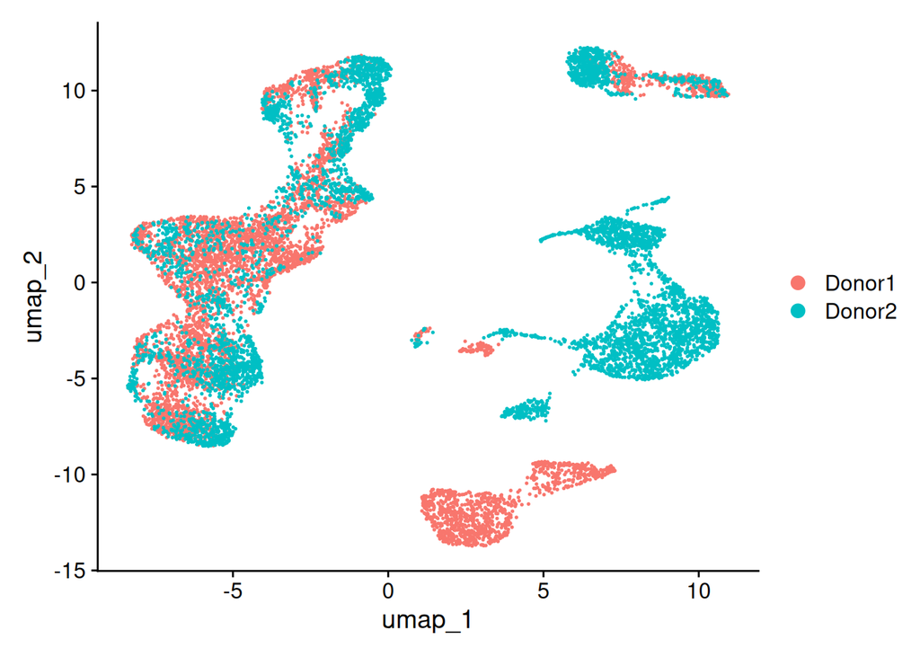

```r
Seurat::DimPlot(scData, reduction = "umap")
```

To perform the integration, we split our object by sample, resulting into a set of layers within the `RNA` assay. The layers are integrated and stored in the reduction slot - in our case we call it `integrated.cca`. Then, we re-join the layers

```r
scData[["RNA"]] <- split(scData[["RNA"]], f = scData$orig.ident)

scData <- Seurat::IntegrateLayers(object = scData, method = CCAIntegration,
                                  orig.reduction = "pca",
                                  new.reduction = "integrated.cca",
                                  verbose = FALSE)

# re-join layers after integration
scData[["RNA"]] <- JoinLayers(scData[["RNA"]])
```

We can then use this new integrated matrix for clustering and visualization. Now, we can re-run and visualize the results with UMAP.

Create the UMAP again on the `integrated.cca` reduction:

```r
scData <- RunUMAP(scData, dims = 1:30, reduction = "integrated.cca")
```

Plotting the UMAP:

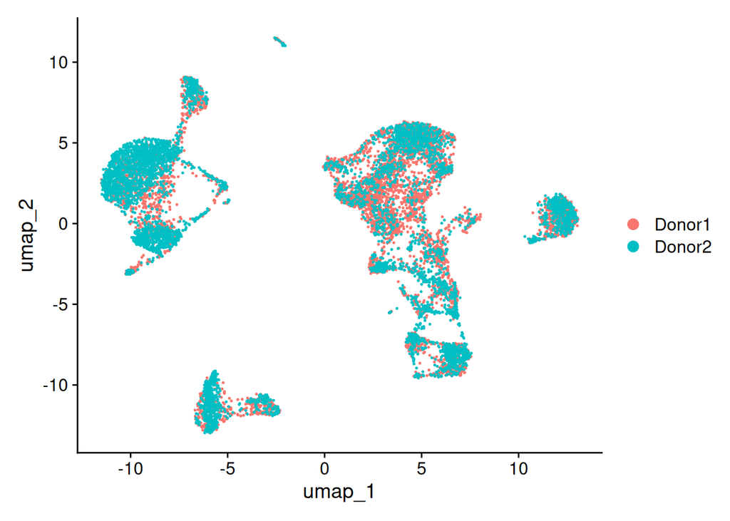

```r
Seurat::DimPlot(scData, reduction = "umap")
```

## Clustering

The method implemented in Seurat first constructs a SNN graph based on the euclidean distance in PCA space, and refine the edge weights between any two cells based on the shared overlap in their local neighborhoods (Jaccard similarity). This step is performed using the `FindNeighbors()` function, and takes as input the previously defined dimensionality of the dataset.

```r
scData <- Seurat::FindNeighbors(scData, dims = 1:25, reduction = "integrated.cca")
```

To cluster the cells, Seurat next implements modularity optimization techniques such as the Louvain algorithm (default) or SLM, to iteratively group cells together, with the goal of optimizing the standard modularity function. The `FindClusters()` function implements this procedure, and contains a resolution parameter that sets the ‘granularity’ of the downstream clustering, with increased values leading to a greater number of clusters.

```r
scData <- Seurat::FindClusters(scData, resolution = seq(0.2, 1.0, by=0.2))
```

Cluster id of each cell is added to the metadata object, as a new column for each resolution tested:

```r
head(scData@meta.data)
```

```
                          orig.ident nCount_RNA nFeature_RNA percent.mito
Donor1_AAACCCTGTGACGAGT-1     Donor1       4891         2103     3.618892
Donor1_AAACGAATCAGGCTAC-1     Donor1      12498         3564     3.768603
Donor1_AAACGACAGATTGACT-1     Donor1      22197         4370     3.126549
Donor1_AAACGATGTCTTGAAC-1     Donor1      10305         2945     3.114993
Donor1_AAACGATGTGCGCGAA-1     Donor1      15947         4160     3.724839
Donor1_AAACGATGTTAGCCCA-1     Donor1       5975         2422     4.033473
                          percent.ribo percent.globin RNA_snn_res.0.2
Donor1_AAACCCTGTGACGAGT-1     1.063177     0.02044572               1
Donor1_AAACGAATCAGGCTAC-1    22.371579     0.00800128               1
Donor1_AAACGACAGATTGACT-1    13.875749     0.00000000               0
Donor1_AAACGATGTCTTGAAC-1    22.775352     0.00000000               1
Donor1_AAACGATGTGCGCGAA-1    19.614975     0.01254154               4
Donor1_AAACGATGTTAGCCCA-1     8.887029     0.01673640               1
                          RNA_snn_res.0.4 RNA_snn_res.0.6 RNA_snn_res.0.8
Donor1_AAACCCTGTGACGAGT-1               8               8               8
Donor1_AAACGAATCAGGCTAC-1               1               1               2
Donor1_AAACGACAGATTGACT-1               0               0               0
Donor1_AAACGATGTCTTGAAC-1               1               1               2
Donor1_AAACGATGTGCGCGAA-1               7               6               5
Donor1_AAACGATGTTAGCCCA-1               8               8               8
                          RNA_snn_res.1 seurat_clusters
Donor1_AAACCCTGTGACGAGT-1             9               9
Donor1_AAACGAATCAGGCTAC-1             3               3
Donor1_AAACGACAGATTGACT-1             1               1
Donor1_AAACGATGTCTTGAAC-1             3               3
Donor1_AAACGATGTGCGCGAA-1             5               5
Donor1_AAACGATGTTAGCCCA-1             9               9
```

### Clustree

To view how clusters sub-divide at increasing resolution:

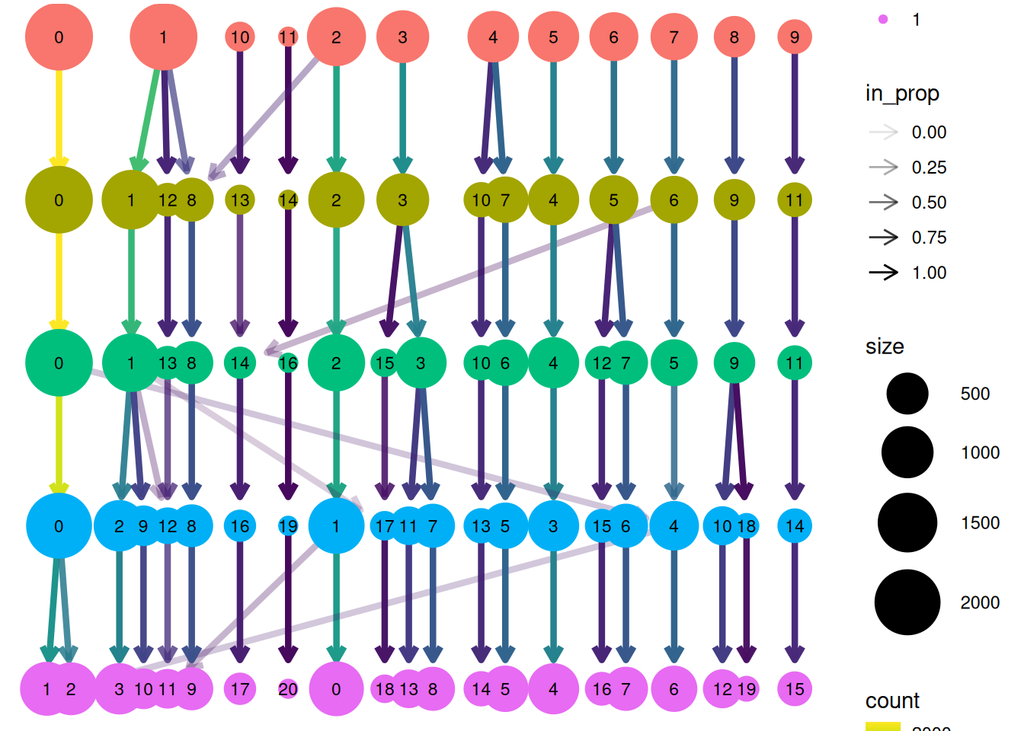

```r
library(clustree)
clustree::clustree(scData@meta.data[,grep("RNA_snn_res", colnames(scData@meta.data))],
                   prefix = "RNA_snn_res.")
```

You can view the UMAP coloring each cell according to a cluster id like this:

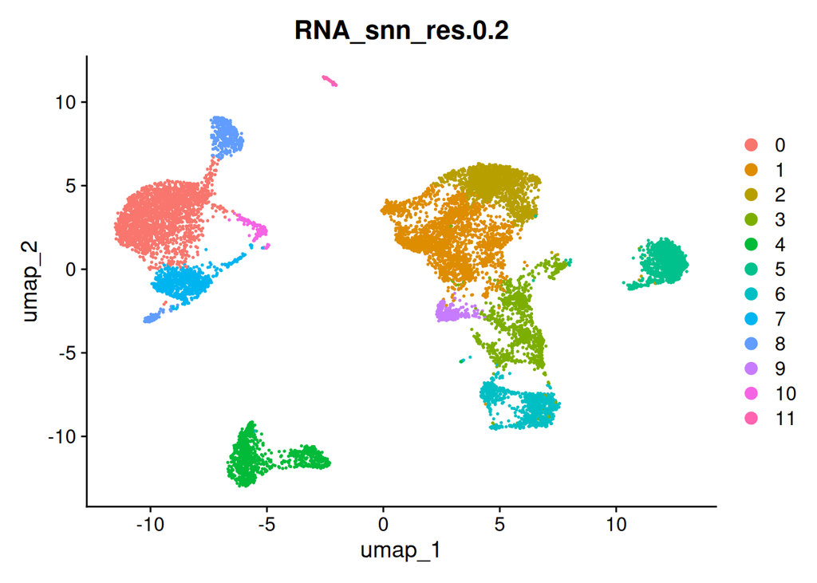

```r
Seurat::DimPlot(scData, group.by = "RNA_snn_res.0.2")
```

Visualise clustering based on a few more resolutions:

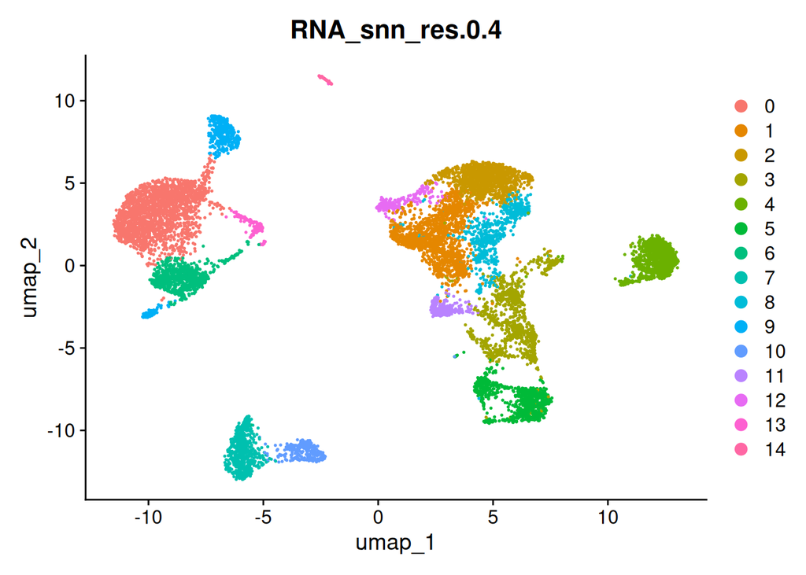

```r
Seurat::DimPlot(scData, group.by = "RNA_snn_res.0.4")
```

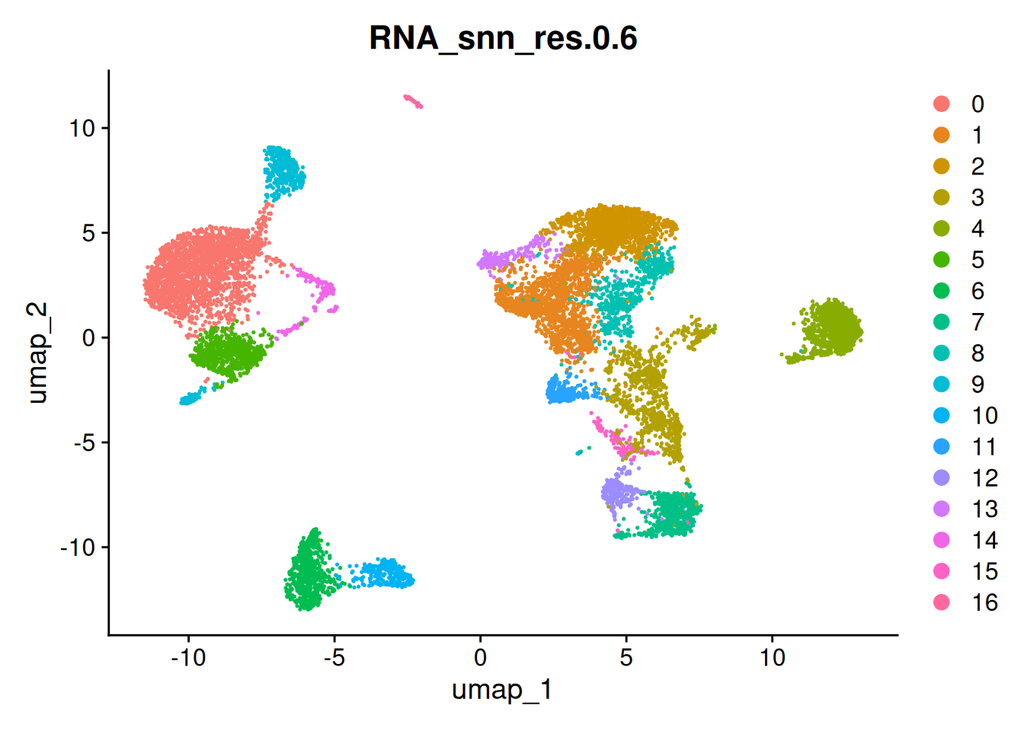

```r
Seurat::DimPlot(scData, group.by = "RNA_snn_res.0.6")
```

Based on resolution of 0.4, the tree stays relatively stable for a few resolution steps, and it seems that clustering fits the UMAP well. Let’s set this as our default clustering:

```r
scData <- Seurat::SetIdent(scData, value = scData$RNA_snn_res.0.4)
```

## Cell Annotation

Load the following packages:

```r
library(celldex)
library(SingleR)
```

During cell annotation we will use the original count data (not the integrated data):

```r
DefaultAssay(scData) <- "RNA"
```

Based on the UMAP we have generated, we can visualize expression for a gene in each cluster:

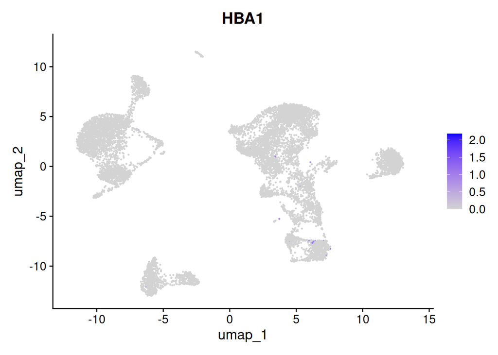

```r
Seurat::FeaturePlot(scData, "HBA1")
```

Based on expression of sets of genes you can do a manual cell type annotation. If you know the marker genes for some cell types, you can check whether they are up-regulated in one or the other cluster. Here we have some marker genes for different cell types:

```r
tcell_genes <- c("IL7R", "LTB", "TRAC", "CD3D")
bcell_genes <- c("CD19", "CD79A", "CD79B", "MS4A1")
monocyte_genes <- c("CD14", "CST3", "CD68", "CTSS")
nk_genes <- c("GNLY", "NKG7", "GZMA", "KLRD1")
```

Let’s have a look at the expression of the four T cell genes:

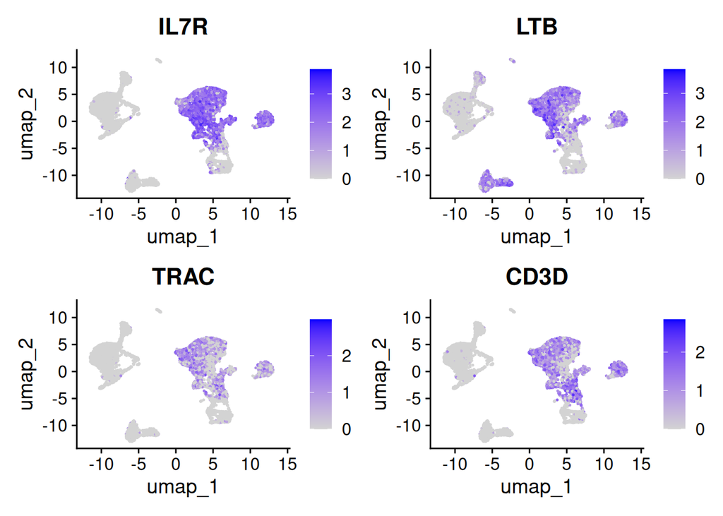

```r
Seurat::FeaturePlot(scData, tcell_genes, ncol=2)
```

Which becomes clearer when looking at the violin plot:

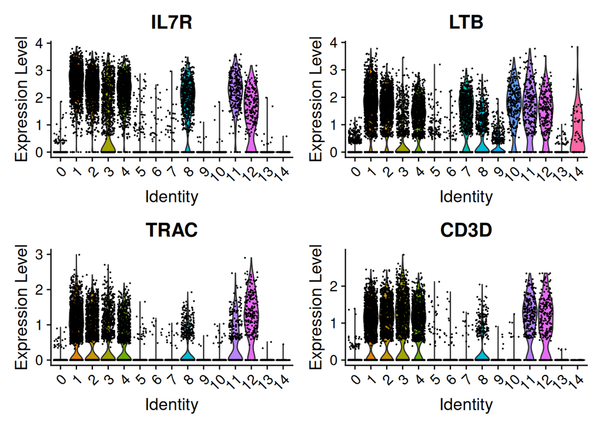

```r
Seurat::VlnPlot(scData,
                features = tcell_genes,
                ncol = 2)
```

Have a look at the B cell and monocyte genes as well:

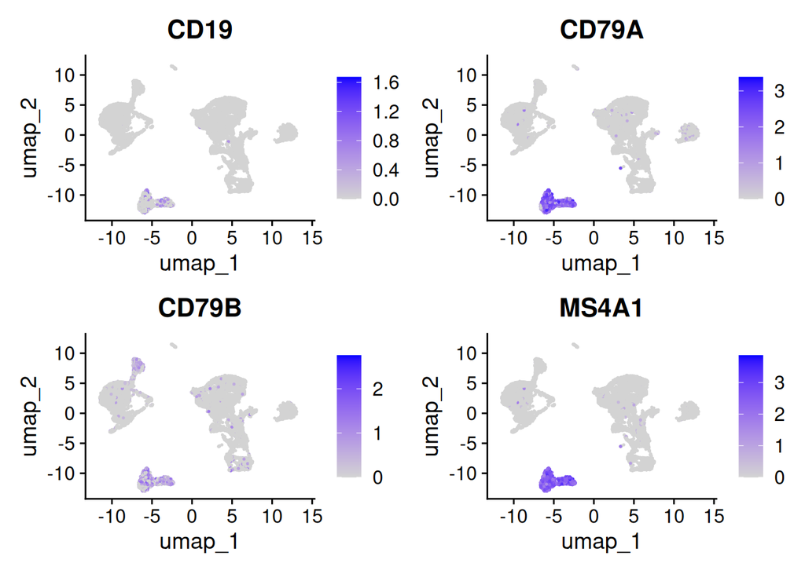

```r
Seurat::FeaturePlot(scData, bcell_genes, ncol=2)
```

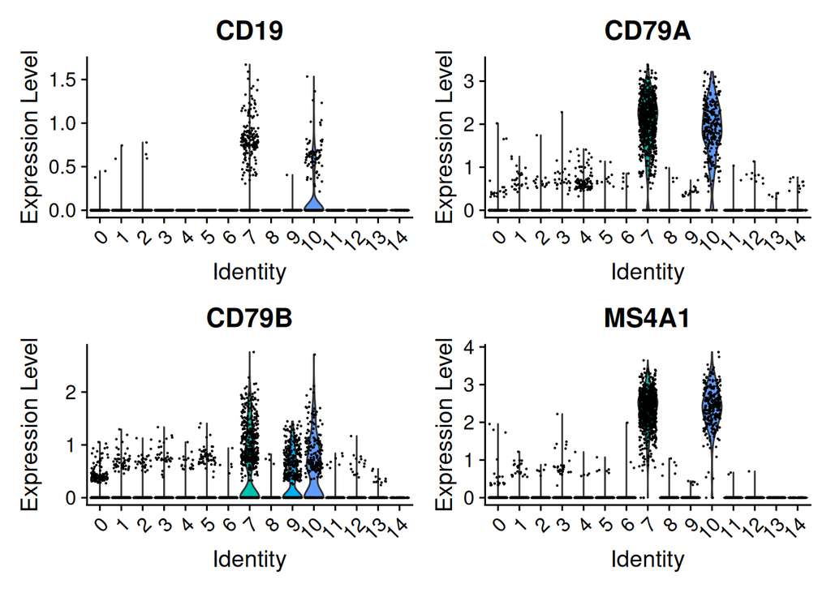

```r
Seurat::VlnPlot(scData,
                features = bcell_genes,
                ncol = 2)
```

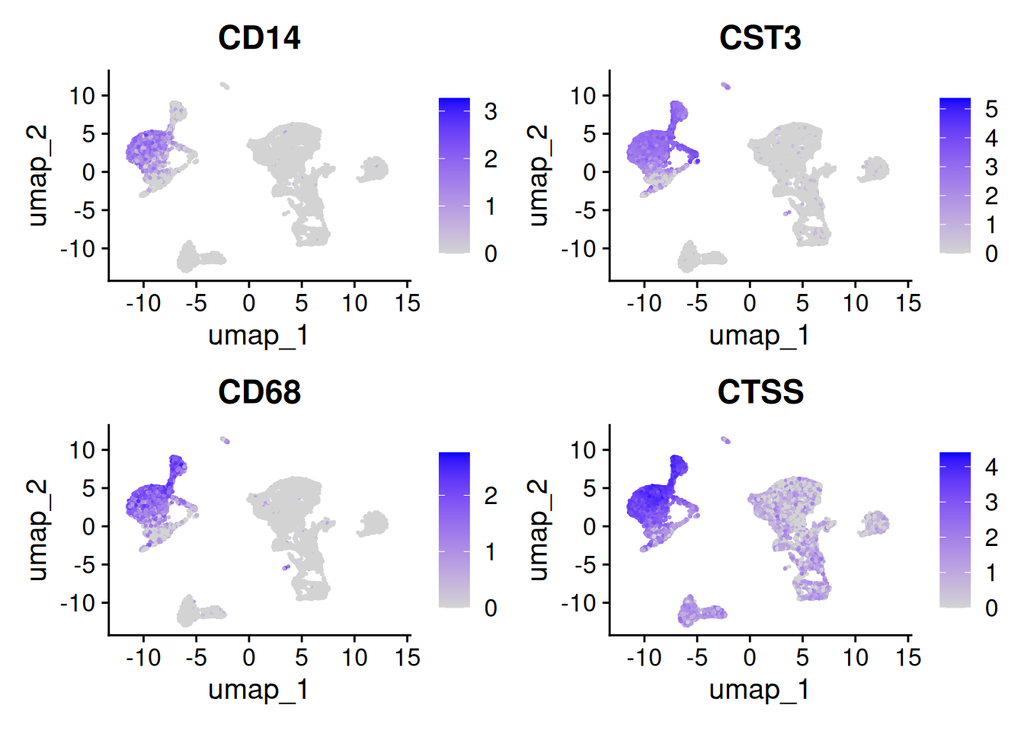

```r
Seurat::FeaturePlot(scData, monocyte_genes, ncol=2)
```

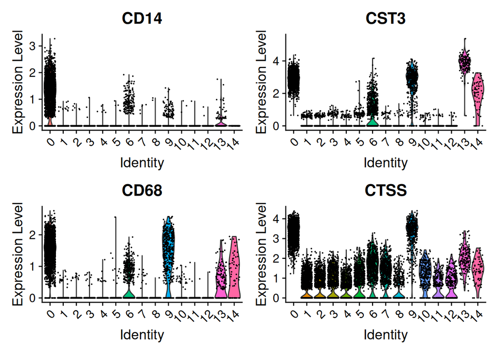

```r
Seurat::VlnPlot(scData,
                features = monocyte_genes,
                ncol = 2)
```

We can also automate this with the function `AddModuleScore`. For each cell, an expression score for a group of genes is calculated:

```r
scData <- Seurat::AddModuleScore(scData,
                                 features = list(tcell_genes),
                                 name = "tcell_genes")
```

After running `AddModuleScore`, a column was added to `scData@meta.data` called `tcell_genes1`. It contains the module score for each cell (which is basically the average expression of the set of genes).

You can plot the UMAP with

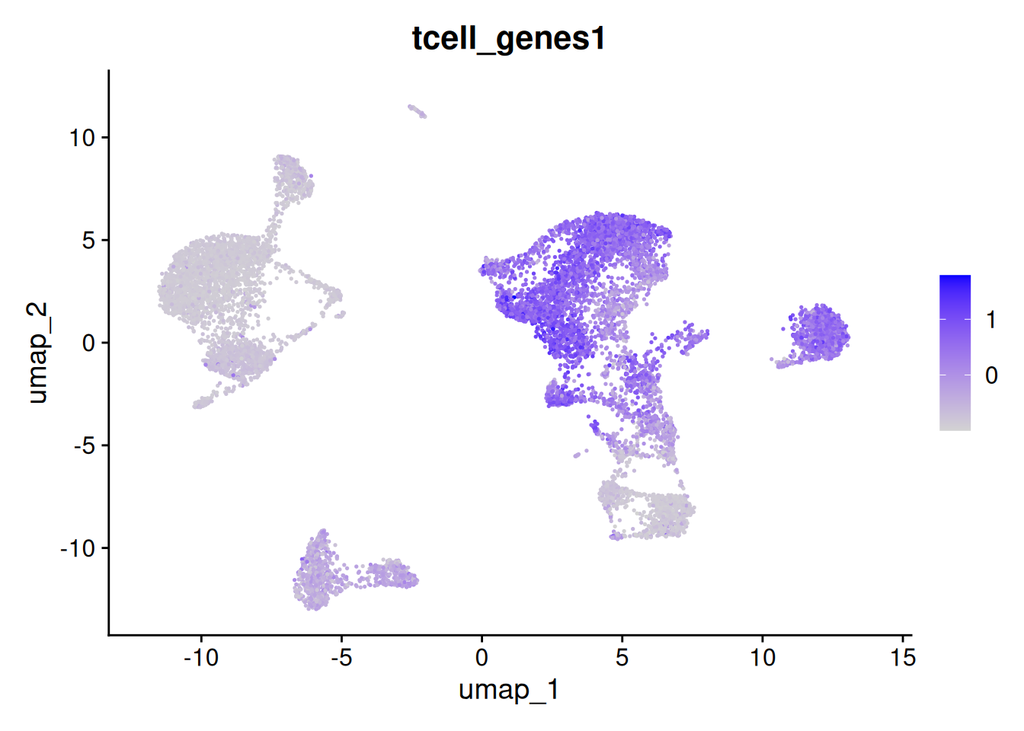

```r
Seurat::FeaturePlot(scData, "tcell_genes1")
```

Which shows these genes are mainly expressed in certain clusters:

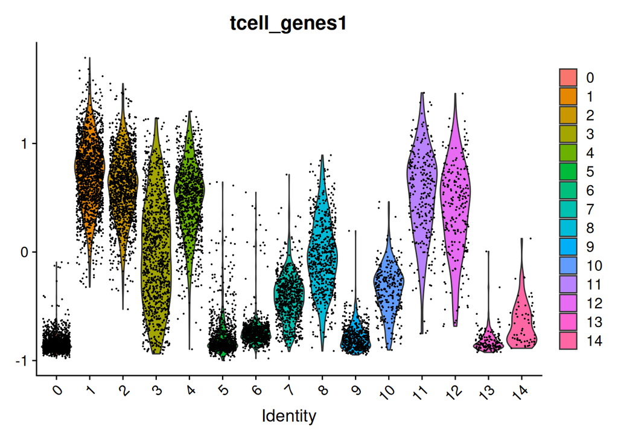

```r
Seurat::VlnPlot(scData,
                "tcell_genes1")
```

### Annotating cells according to cycling phase

Based on the same principle, we can also annotate cell cycling state. The function `CellCycleScore` uses `AddModuleScore` to get a score for the G2/M and S phase (the mitotic phases in which cell is cycling). In addition, `CellCycleScore` assigns each cell to either the G2/M, S or G1 phase.

First we extract the built-in genes for cell cycling:

```r
s.genes <- Seurat::cc.genes.updated.2019$s.genes
g2m.genes <- Seurat::cc.genes.updated.2019$g2m.genes
```

Now we run the function:

```r
scData <- Seurat::CellCycleScoring(scData,
                                   s.features = s.genes,
                                   g2m.features = g2m.genes)
```

And we can visualize the annotations:

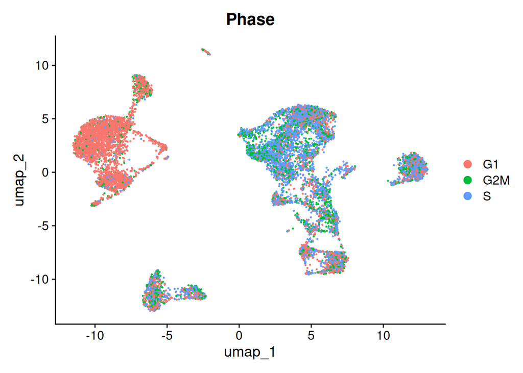

```r
Seurat::DimPlot(scData, group.by = "Phase")
```

Cell cycle information can be useful to keep in mind when interpreting downstream analyses.

### Cell type annotation using `SingleR`

To do a fully automated annotation, we need a reference dataset of primary cells. Here we are using a hematopoietic reference dataset from `celldex`. Check out what’s in there:

```r
ref <- celldex::NovershternHematopoieticData()
class(ref)
table(ref$label.main)
```

[output not shown]

Now `SingleR` compares our normalized count data to a reference set, and finds the most probable annotation:

```r
scData_SingleR <- SingleR::SingleR(test = Seurat::GetAssayData(scData),
                                   ref = ref,
                                   labels = ref$label.main)
```

See what’s in there by using `head`:

```r
head(scData_SingleR)
```

```
DataFrame with 6 rows and 4 columns
                                                  scores       labels
                                                <matrix>  <character>
Donor1_AAACCCTGTGACGAGT-1 0.248058:0.138436:0.359456:... CD4+ T cells
Donor1_AAACGAATCAGGCTAC-1 0.330869:0.203598:0.462598:... CD4+ T cells
Donor1_AAACGACAGATTGACT-1 0.310532:0.300673:0.270932:...    Monocytes
Donor1_AAACGATGTCTTGAAC-1 0.307333:0.194588:0.431520:... CD4+ T cells
Donor1_AAACGATGTGCGCGAA-1 0.497694:0.363757:0.337637:...      B cells
Donor1_AAACGATGTTAGCCCA-1 0.270457:0.173731:0.375372:... CD4+ T cells
                          delta.next pruned.labels
                           <numeric>   <character>
Donor1_AAACCCTGTGACGAGT-1  0.1484061  CD4+ T cells
Donor1_AAACGAATCAGGCTAC-1  0.0822642  CD4+ T cells
Donor1_AAACGACAGATTGACT-1  0.0647324     Monocytes
Donor1_AAACGATGTCTTGAAC-1  0.1204955  CD4+ T cells
Donor1_AAACGATGTGCGCGAA-1  0.1339370       B cells
Donor1_AAACGATGTTAGCCCA-1  0.0897359  CD4+ T cells
```

Visualize singleR score quality scores:

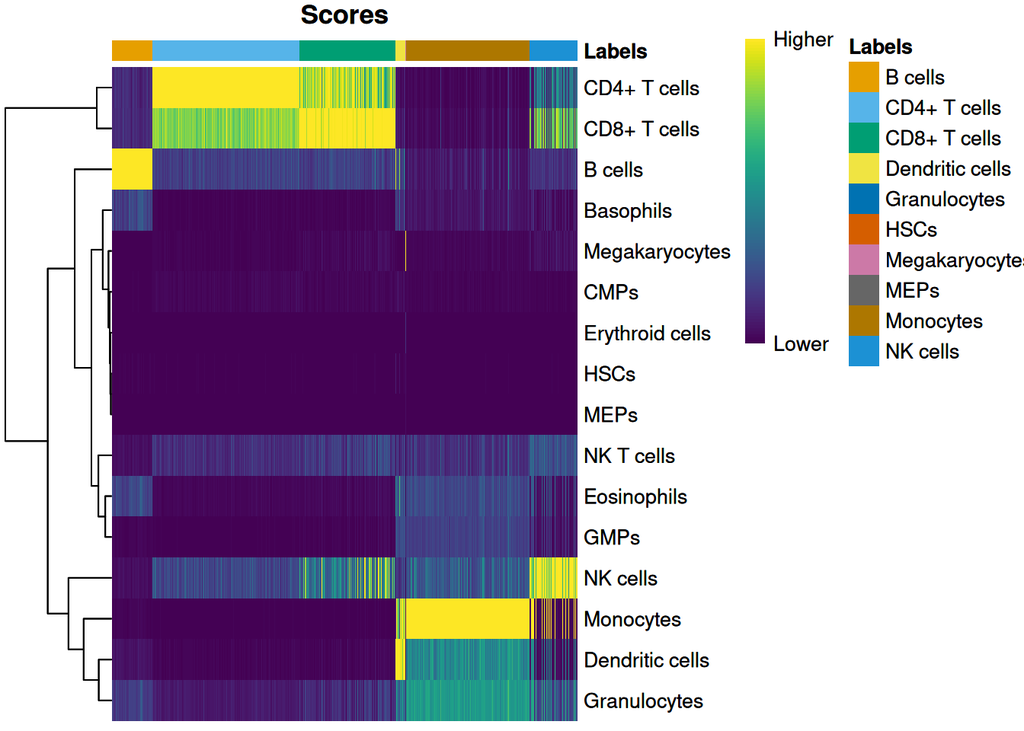

```r
SingleR::plotScoreHeatmap(scData_SingleR)
```

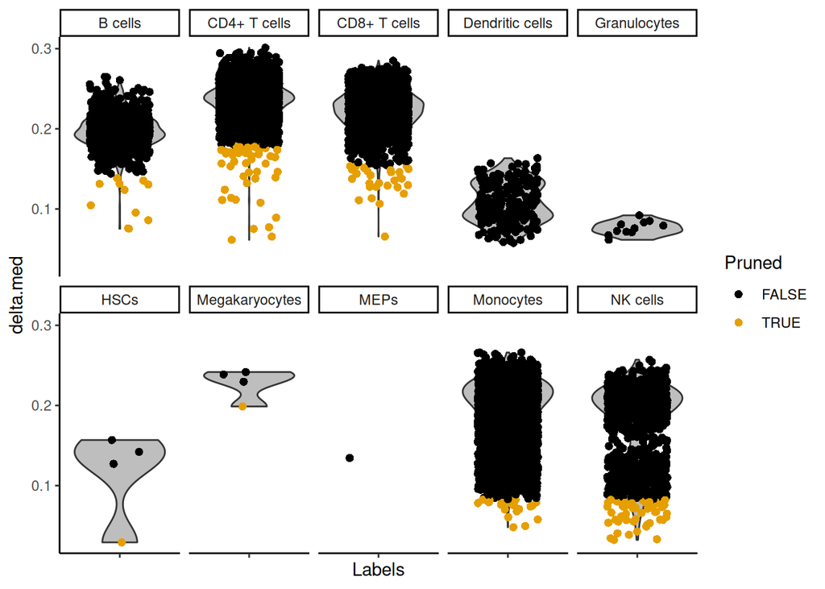

```r
SingleR::plotDeltaDistribution(scData_SingleR)
```

There are some annotations that contain only a few cells. They are usually not of interest, and they clog our plots. Therefore we remove them from the annotation:

```r
singleR_labels <- scData_SingleR$labels
t <- table(singleR_labels)
other <- names(t)[t < 10]
singleR_labels[singleR_labels %in% other] <- "none"
```

In order to visualize it in our UMAP, we have to add the annotation to `scData@meta.data`:

```r
scData$SingleR_annot <- singleR_labels
```

We can plot the annotations in the UMAP. Here, we use a different package for plotting (`dittoSeq`) as it has a bit better default coloring:

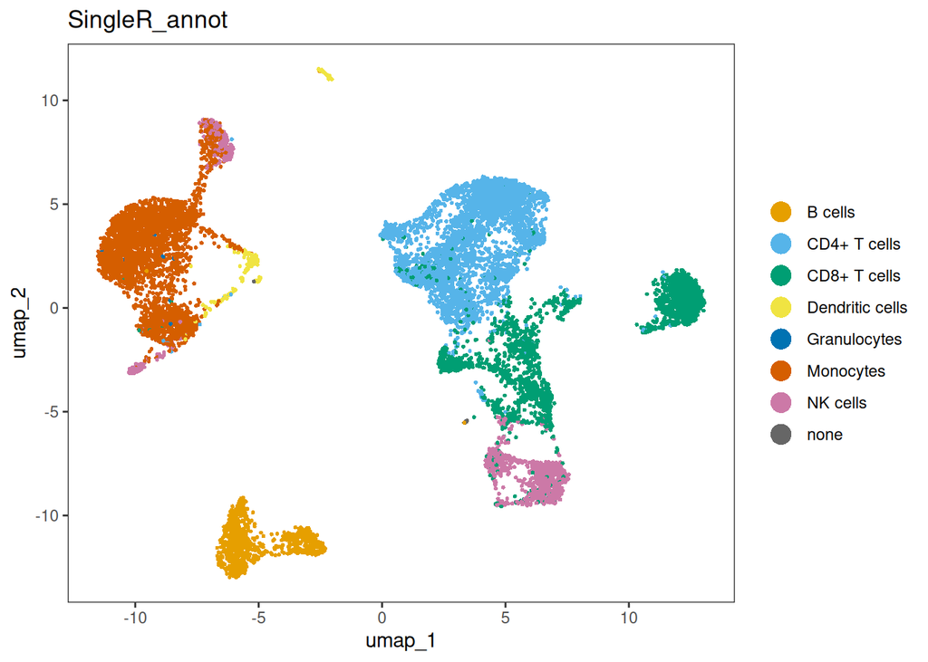

```r
library(dittoSeq)
dittoSeq::dittoDimPlot(scData, "SingleR_annot", size = 0.7)
```

We can check out how many cells per sample we have for each annotated cell type:

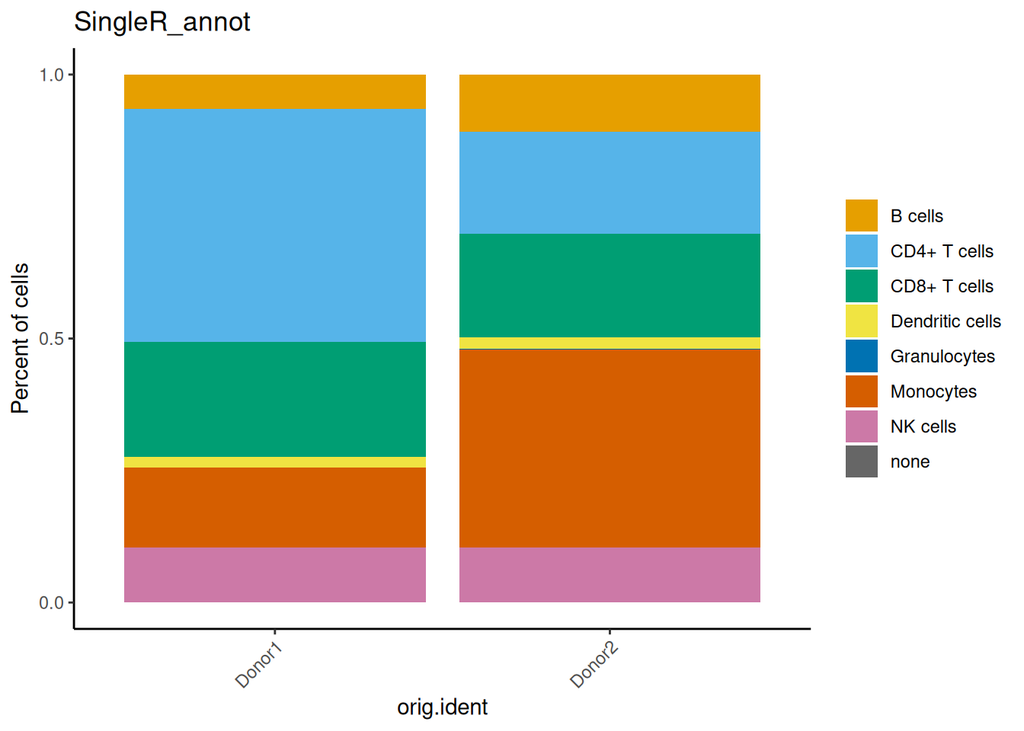

```r
dittoSeq::dittoBarPlot(scData, var = "SingleR_annot", group.by = "orig.ident")
```

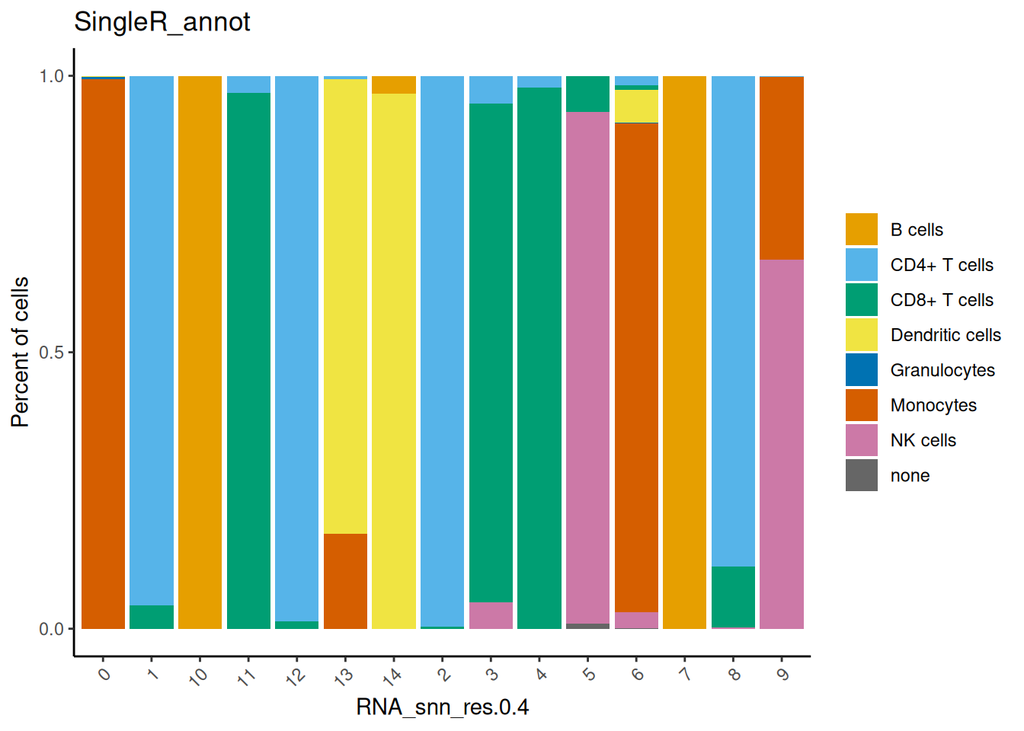

```r
dittoSeq::dittoBarPlot(scData,
                       var = "SingleR_annot",
                       group.by = "RNA_snn_res.0.4")
```

### Comparing with the automated 10x cell annotation

You might have noticed that Donor1 actually came with a cell annotation file already present: `~/work/5k-human-pbmc-3p-gem-x/Donor1/cell_types` .

Let’s load this result and compare it against the celltype annotation we got from SingleR

```r
# read in the celltypes
cellTypes <- vroom::vroom("~/work/5k-human-pbmc-3p-gem-x/Donor1/cell_types/cell_types.csv", delim=",")
# create a named vector mapping cells to labels
cellTypes$barcode <- paste0("Donor1_", cellTypes$barcode)
cellTypeLabel <- cellTypes$coarse_cell_type
names(cellTypeLabel) <- cellTypes$barcode

# Create a named vector for all unlabeled cells in our dataset
cellTypeUnlabeledCells <- setdiff(colnames(scData), cellTypes$barcode)
cellTypeUnlabeled <- rep(NA, length(cellTypeUnlabeledCells))
names(cellTypeUnlabeled) <- cellTypeUnlabeledCells

# Merge
cellTypeLabel <- c(cellTypeLabel, cellTypeUnlabeled)

scData <- AddMetaData(scData, cellTypeLabel, col.name="TenX_annot")
```

And repeat the visualisation on our reduced dimensionality

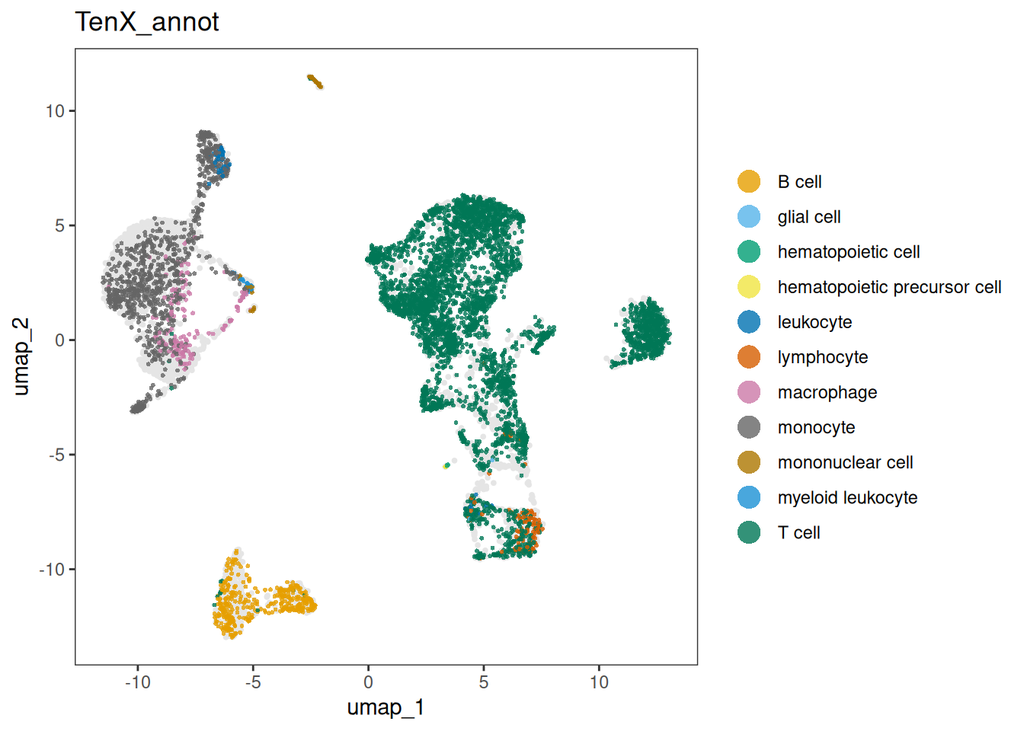

```r
dittoSeq::dittoDimPlot(scData, "TenX_annot", size = 0.7,
                       cells.use = !is.na(scData$TenX_annot),
                       show.others = TRUE,
                       opacity=0.8)
```

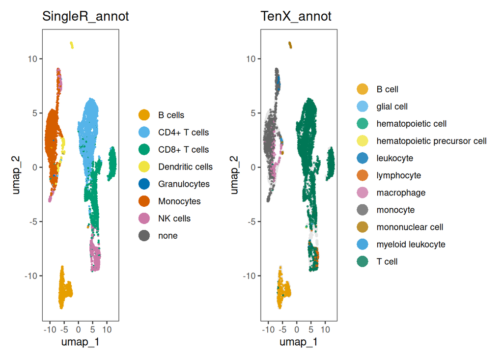

```r
dittoSeq::dittoDimPlot(scData, "SingleR_annot", size = 0.7) |
  dittoSeq::dittoDimPlot(scData, "TenX_annot", size = 0.7,
                       cells.use = !is.na(scData$TenX_annot),
                       show.others = TRUE,
                       opacity=0.8)
```

## Differential Expression Analysis

The function FindAllMarkers performs a Wilcoxon plot to determine the genes differentially expressed between each cluster and the rest of the cells. Other types of tests than the Wilcoxon test are available. Check it out by running `?Seurat::FindAllMarkers`.

**Runtimes**

It can take quite some time on limited computational setups (1.5 minutes per cluster).

Now run analysis.

```r
# Here we load the result if we have saved it before to save time
de_genes_fn <- "de_genes_FindAllMarkers.csv"
if (file.exists(de_genes_fn)) {
  de_genes <- vroom::vroom(de_genes_fn, delim="\t")
} else {
  de_genes <- FindAllMarkers(scData,  min.pct = 0.25, only.pos = TRUE)
}
```

Subset the table to only keep the significant genes, and you can save it as a csv file if you wish to explore it further. Then extract the top 5 markers per cluster:

```r
de_genes <- subset(de_genes, de_genes$p_val_adj < 0.05)
vroom::vroom_write(de_genes,
                   "de_genes_FindAllMarkers.csv",
                   delim="\t")

top_specific_markers <- de_genes %>%
  group_by(cluster) %>%
  top_n(5, avg_log2FC)
```

And generate e.g. a dotplot:

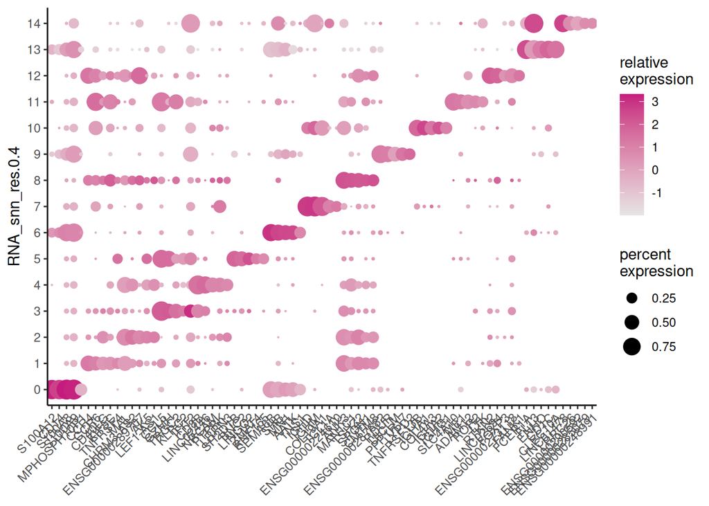

```r
dittoSeq::dittoDotPlot(scData,
                       vars = unique(top_specific_markers$gene),
                       group.by = "RNA_snn_res.0.4")
```

Are the T cell genes in there? You can re-load the vector with immune genes and plot them.

```r
tcell_genes <- c("IL7R", "LTB", "TRAC", "CD3D")
```